```r
library(TSA)
data <- read.csv("D:\\МГУ\\Практикум на ЭВМ\\Task_4\\var_15.csv")
export_data <- data[, -1]
```

Преобразуем данные в объект класса ts (временной ряд), задав начало ряда как 2017-й год и частоту 52 (периодизация по неделям) и построим график

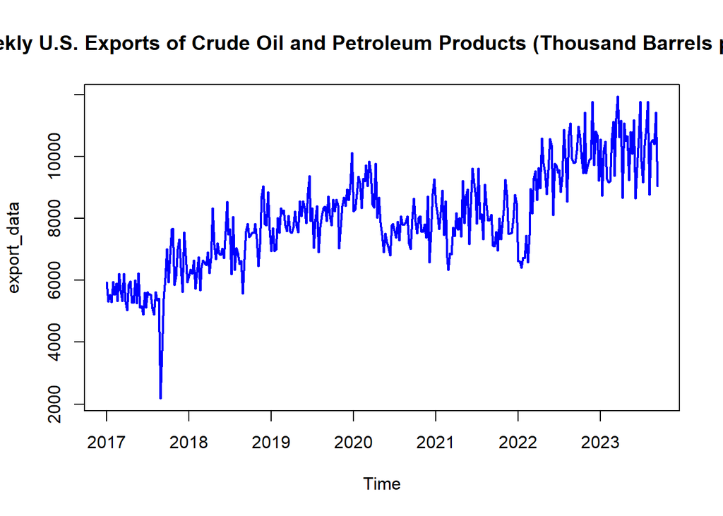

```r
export_data <- ts(export_data ,start= c(2017,1),frequency = 52)
plot(export_data, type = "l", col = "blue",lwd = 2,
     main='Weekly U.S. Exports of Crude Oil and Petroleum Products (Thousand Barrels per Day)')
```

# Построение модели

Видно, что ряд не стационарный. Перейдем к разностям. Берём первое дифференцирование временного ряда, чтобы удалить тренд

```r
y <- diff(export_data)
```

Берём сезонное дифференцирование с лагом 52 недели, что позволяет учесть годовую сезонность в данных и построим график временного ряда из сезонных разностей

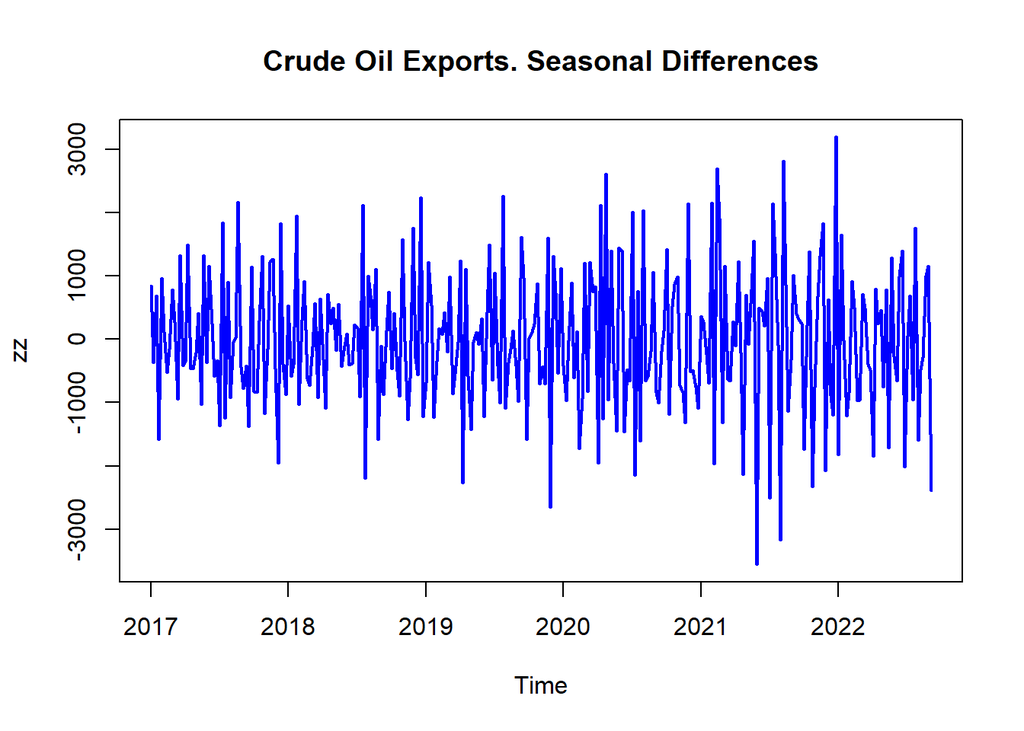

```r
z <- diff(y, lag = 52)
zz <- ts(z, start = c(2017, 1), frequency = 52)
plot(zz, type = "l", col = "blue", lwd = 2, main = "Crude Oil Exports. Seasonal Differences")
```

Урезаем временной ряд до первых 237 точек, чтобы на них построить модель

```r
zz <- zz[1:237]
```

Строим автокорреляционную (ACF) и частную автокорреляционную (PACF) функции для предъявления порядков моделей SARMA

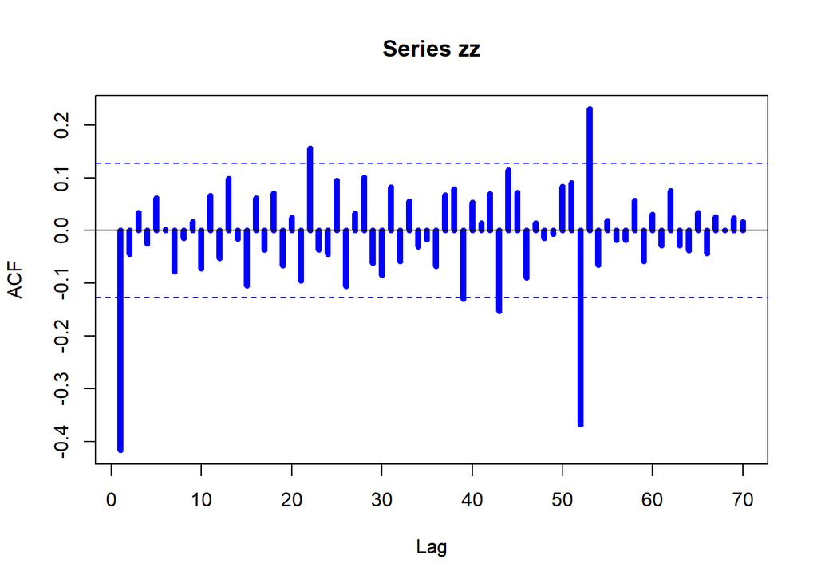

```r
acf(zz,lwd = 5, col = "blue", lag=70)
```

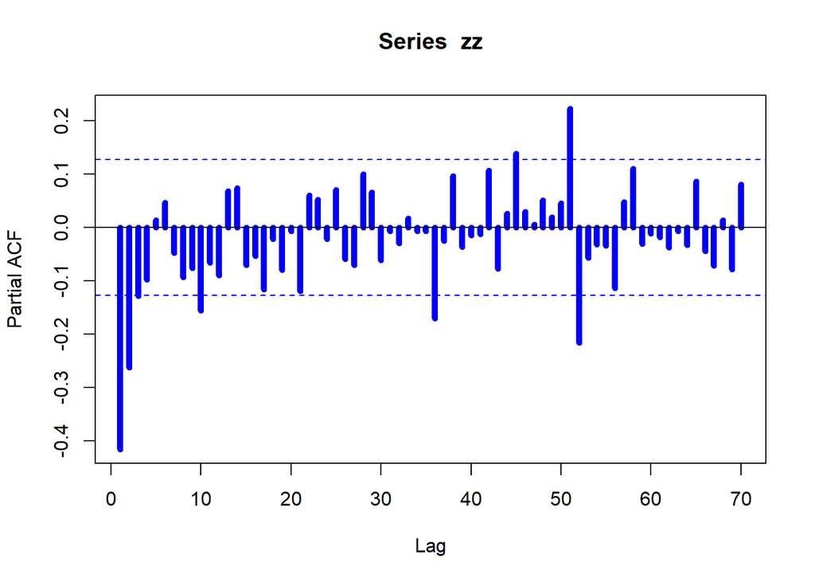

```r
pacf(zz,lwd = 5, col = "blue", lag=70)
```

В качестве первой модели возьмем авторегрессию 10-го порядка несезонной компоненты и 1-го порядка сезонной компоненты с периодичностью 52

```r
ar_model_export <- arima(zz, order = c(10,0,0), seasonal = list(order= c(1,0,0),period = 52), method = "ML")
ar_model_export$coef
```

```
##          ar1          ar2          ar3          ar4          ar5          ar6
## -0.584960193 -0.375171732 -0.178762895 -0.092623814 -0.007924564 -0.051968153
##          ar7          ar8          ar9         ar10         sar1    intercept
## -0.169505945 -0.131210550 -0.187943676 -0.130563420 -0.488804759  2.838073184
```

```r
ar_model_export$sigma2
```

```
## [1] 659378.3
```

```r
ar_model_export$aic
```

```
## [1] 3887.139
```

Итак SARMA модель идентифицирована, порядки модели выбраны, модель оценена. Возникает вопрос в адекватности построенной модели. О многом могут сказать остатки после удаления оцененной модели. Чаше всего предполагается нормальность белого шума

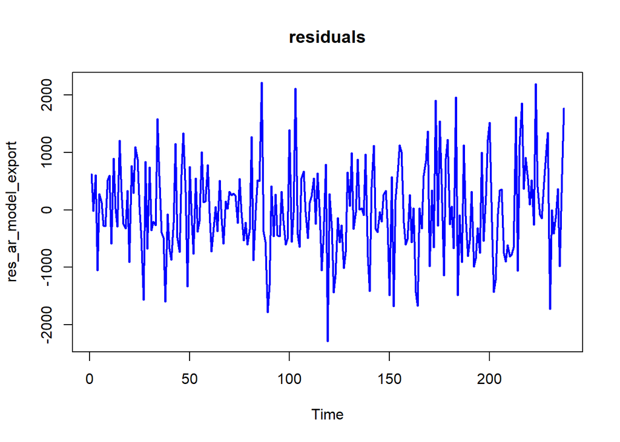

```r
res_ar_model_export <- ar_model_export$residuals
plot.ts(res_ar_model_export,col = "blue",lwd = 2,type = "l", main = "residuals")
```

Эффективным средством для визуальной проверки нормальности является так называемый QQ-график или квантиль-квантиль график. В нем по одной оси выдаются заданные теоретические например нормальные квантили, другой оси выдаются выборочные (по эмпирической функции распределение).

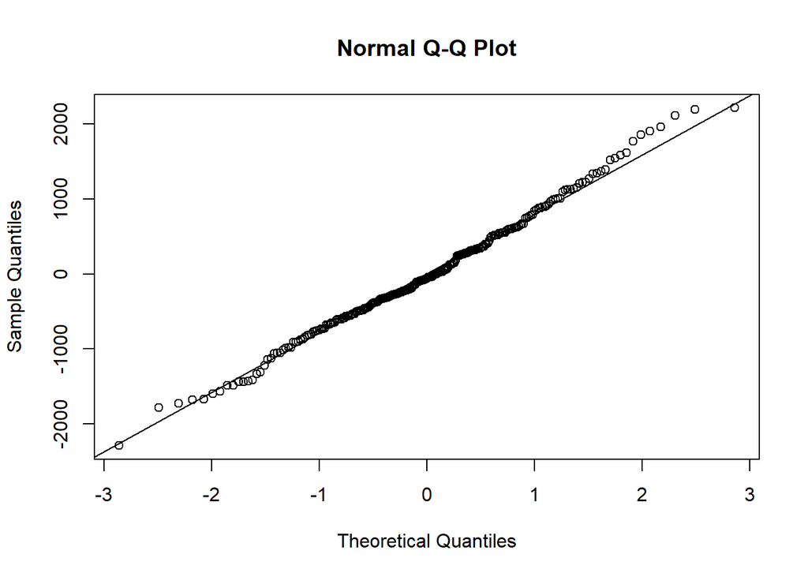

```r
qqnorm(res_ar_model_export)
qqline(res_ar_model_export)
```

Если в остатках белый шум, то значение ACF остатков должны лежать внутри доверительного интервала

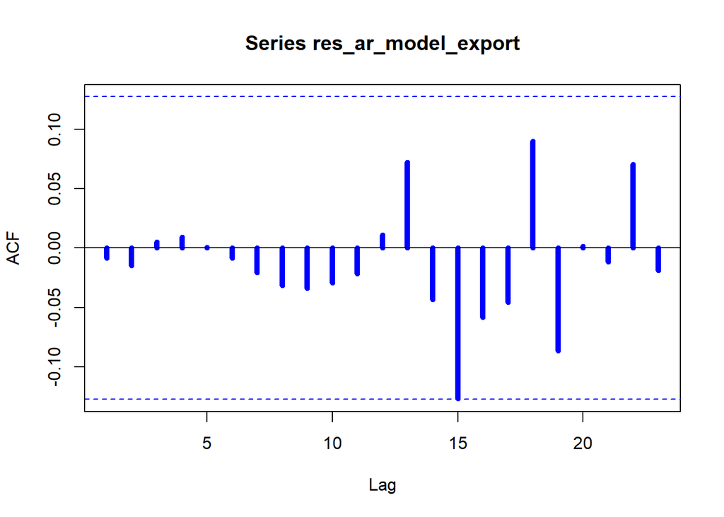

```r
acf(res_ar_model_export,lwd = 5, col = "blue")
```

Видим, что все находится внутри доверительного интервала

При анализе остатков после удаления очень эффективен тест Льюнг-Бокса. Здесь по сути проверяется гипотеза случайности - независимости и одинаковой распределенности, но не в исходных данных, а именно в остатках после удаления модели SARMA, чем и объясняется его полезность. Основная гипотеза: остатки являются случайными (то есть представляют собой белый шум). Что свидетельствует также, что оцененная SARMA модель адекватна и она учла все связи в исходных данных. Альтернатива: данные не являются случайными или это означает, что предложенная SARMA модель не адекватна.

```r
Box.test(res_ar_model_export, lag = 52, type = "Ljung-Box", fitdf = 11)
```

```
##
##  Box-Ljung test
##
## data:  res_ar_model_export
## X-squared = 47.967, df = 41, p-value = 0.2112
```

Не отвергаем гипотезу о случайности остатков

Посмотрим на сглаженную спектральную плотность остатков после удаления модели. Сглаживание производится трехкратной сверткой окна Даниэлла

```r
k3<- kernel('daniell',c(5,5,5))
sp=spec(res_ar_model_export,kernel=k3,log='no',sub='',xlab='Frequency',
        ylab='Smoothed Sample Spectral Density',col = "blue",lwd = 2)
```

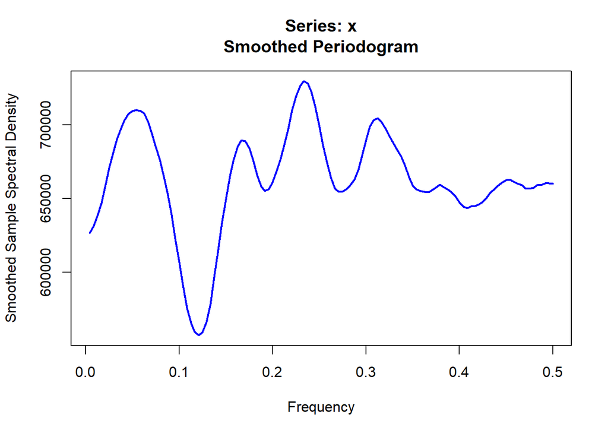

Посмотрим на сглаженную спектральную плотность исходного ряда и остатков для сравнения

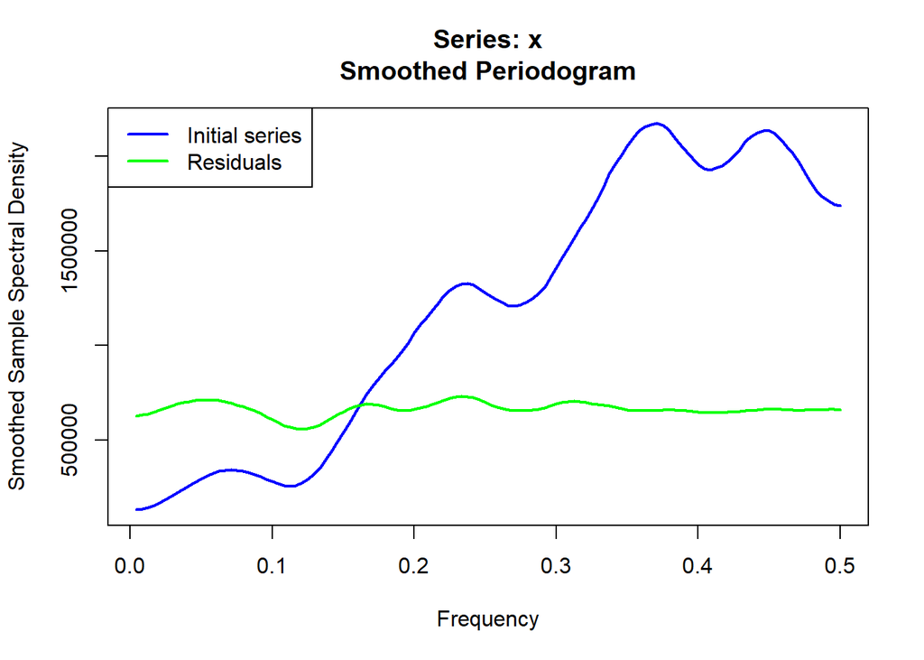

```r
sp_zz=spec(zz,kernel=k3,log='no',sub='',xlab='Frequency',
                       ylab='Smoothed Sample Spectral Density',col = "blue",lwd = 2)
lines(sp$freq,sp$spec,col='green',lwd=2)
legend("topleft",c("Initial series","Residuals"),lwd = 2,col=c("blue","green"))
```

Теперь попробуем модель авторегрессии 3-го порядка несезонной компоненты и 1-го порядка сезонной компоненты с периодичностью 52

```r
ar_model_export_2 <- arima(zz, order = c(3,0,0), seasonal = list(order= c(1,0,0),period = 52), method = "ML")
ar_model_export_2$coef
```

```
##        ar1        ar2        ar3       sar1  intercept
## -0.5582020 -0.3328761 -0.1144024 -0.4890052  3.6689231
```

```r
ar_model_export_2$sigma2
```

```
## [1] 694185
```

```r
ar_model_export_2$aic
```

```
## [1] 3884.937
```

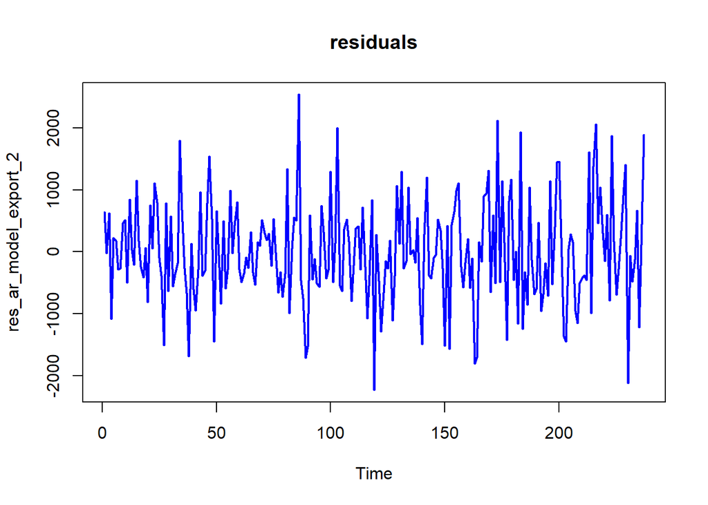

```r
res_ar_model_export_2 <- ar_model_export_2$residuals
plot.ts(res_ar_model_export_2,col = "blue",lwd = 2,type = "l", main = "residuals")
```

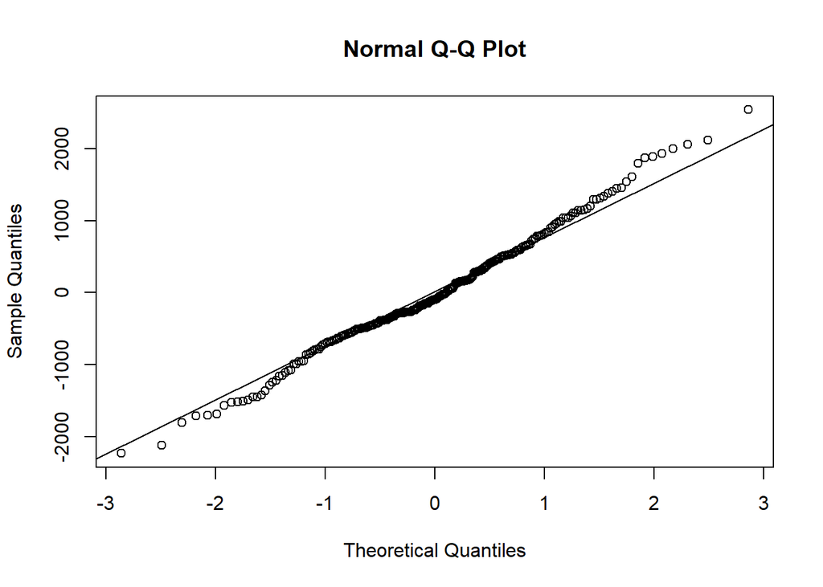

```r
qqnorm(res_ar_model_export_2)
qqline(res_ar_model_export_2)
```

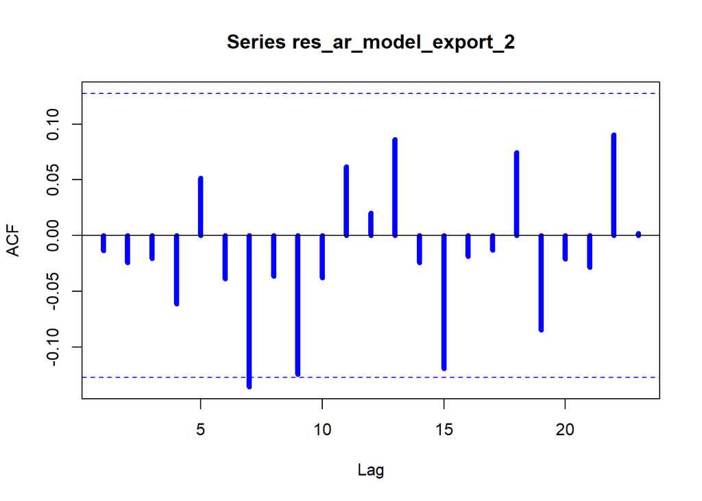

```r
acf(res_ar_model_export_2,lwd = 5, col = "blue")
```

Видно, что остатки выходят за доверительный интервал

```r
Box.test(res_ar_model_export_2, lag = 52, type = "Ljung-Box", fitdf = 4)
```

```
##
##  Box-Ljung test
##
## data:  res_ar_model_export_2
## X-squared = 57.162, df = 48, p-value = 0.1714
```

Не отвергаем гипотезу о случайности остатков

```r
k3<- kernel('daniell',c(5,5,5))
sp_2=spec(res_ar_model_export_2,kernel=k3,log='no',sub='',xlab='Frequency',
        ylab='Smoothed Sample Spectral Density',col = "blue",lwd = 2)
```

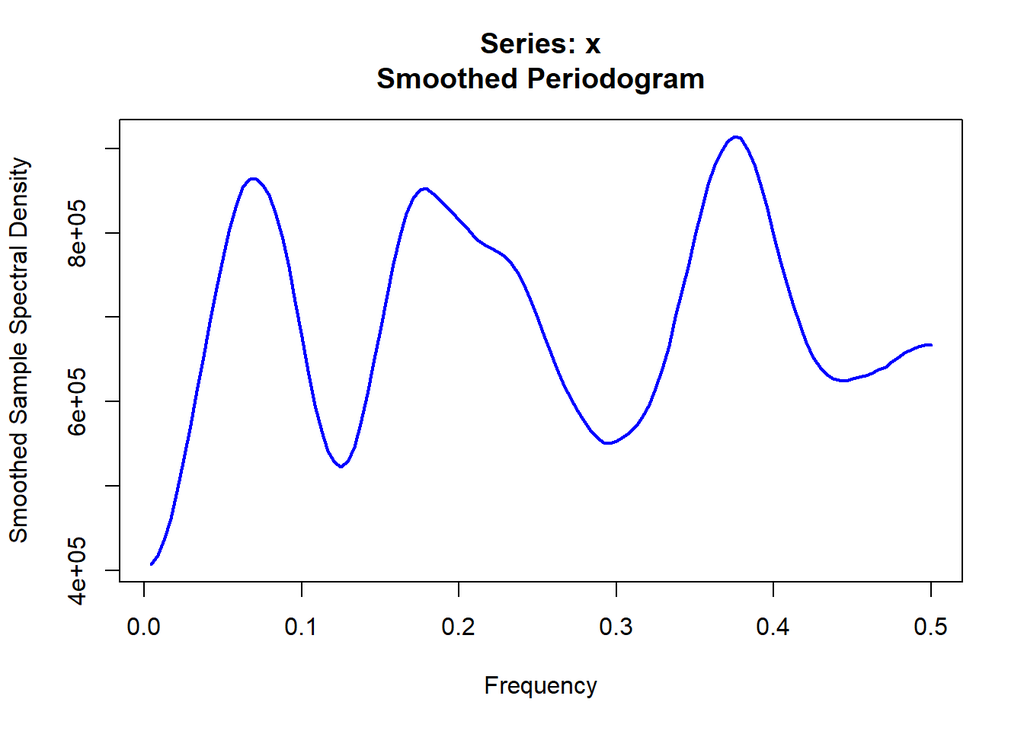

Посмотрим на сглаженную спектральную плотность исходного ряда и остатков обеих моделей для сравнения

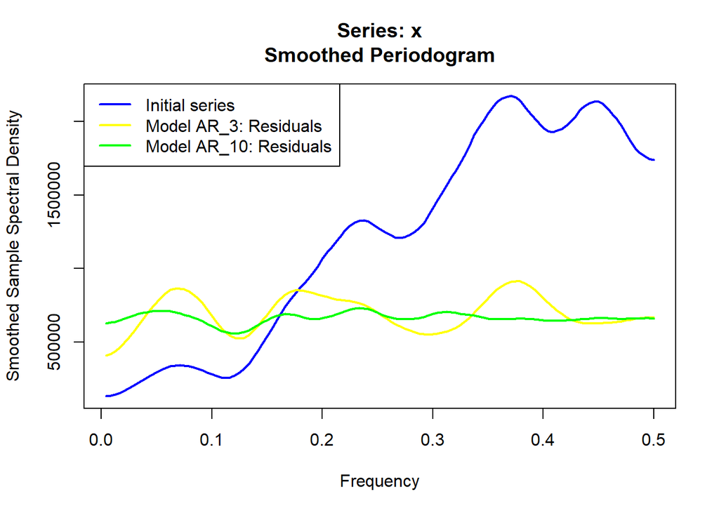

```r
sp_zz = spec(zz,kernel=k3,log='no',sub='',xlab='Frequency',
                       ylab='Smoothed Sample Spectral Density',col = "blue",lwd = 2)
lines(sp_2$freq,sp_2$spec,col='yellow',lwd=2)
lines(sp$freq,sp$spec,col='green',lwd=2)
legend("topleft",c("Initial series","Model AR_3: Residuals", "Model AR_10: Residuals"),lwd = 2,col=c("blue","yellow", "green"))
```

Теперь попробуем модель скользящего среднего порядка 1 несезонной компоненты и порядка 1 сезонной компоненты с периодичностью 52

```r
ma_model_export <- arima(zz, order = c(0,0,1), seasonal = list(order= c(0,0,1),period = 52), method = "ML")
ma_model_export$coef
```

```
##        ma1       sma1  intercept
## -0.5995586 -0.6997936  2.8379511
```

```r
ma_model_export$sigma2
```

```
## [1] 605012.3
```

```r
ma_model_export$aic
```

```
## [1] 3868.129
```

Видим, что критерий Акаике наименьший среди трех моделей, но помним, что он штрафует за количество параметров модели, а у первой их 11

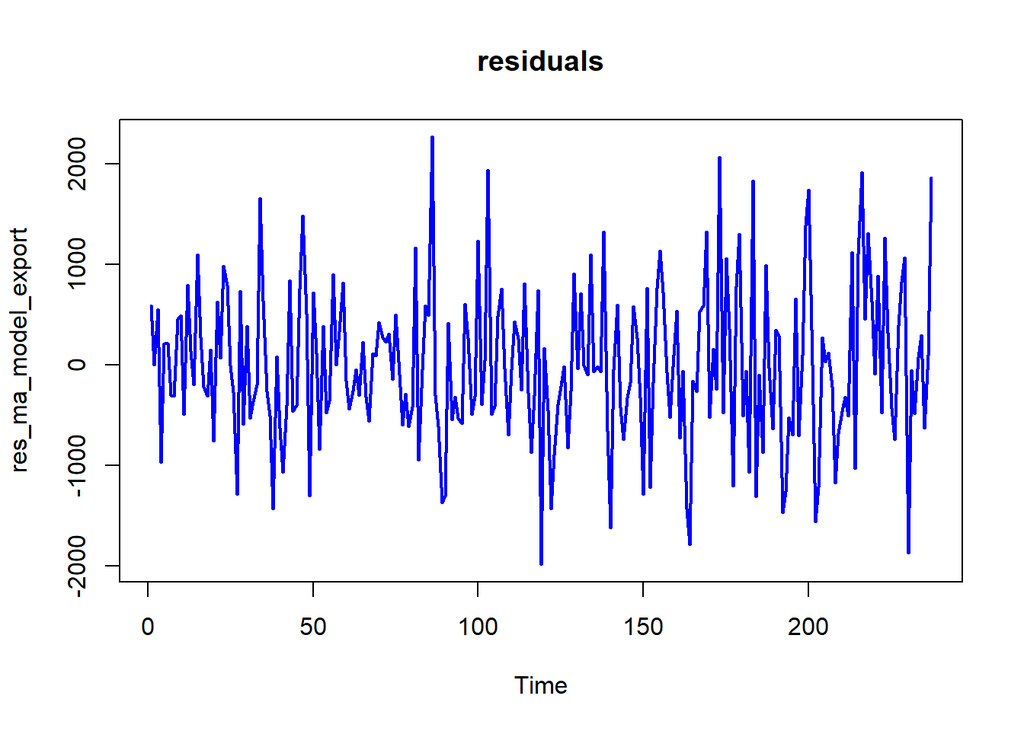

```r
res_ma_model_export <- ma_model_export$residuals
plot.ts(res_ma_model_export,col = "blue",lwd = 2,type = "l", main = "residuals")
```

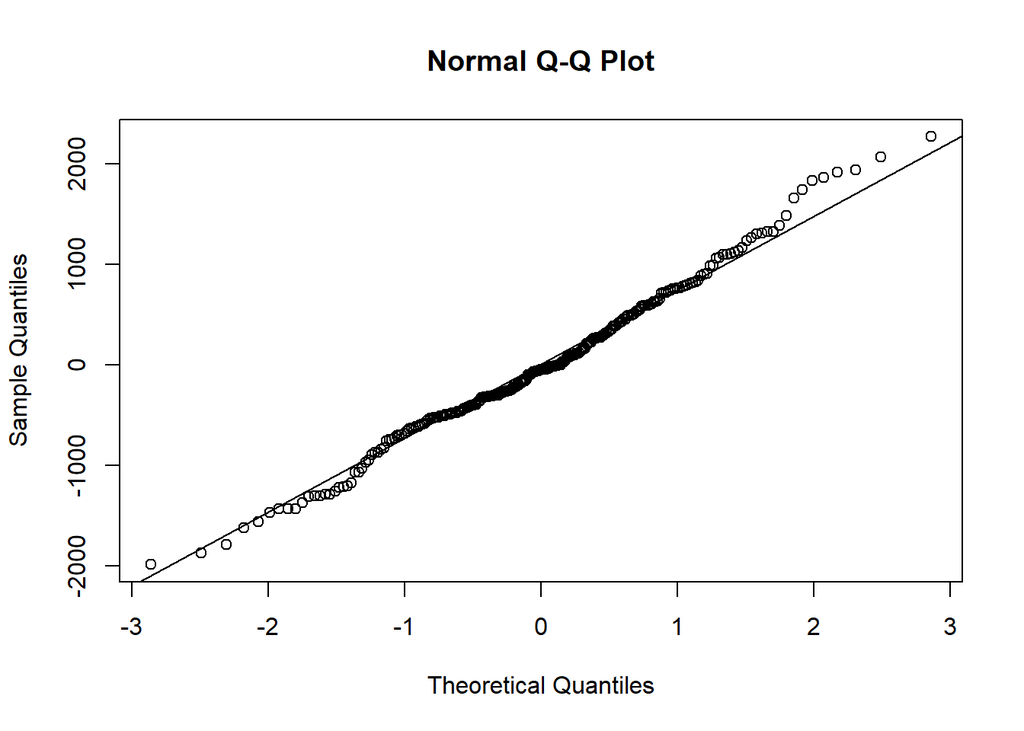

```r
qqnorm(res_ma_model_export)
qqline(res_ma_model_export)
```

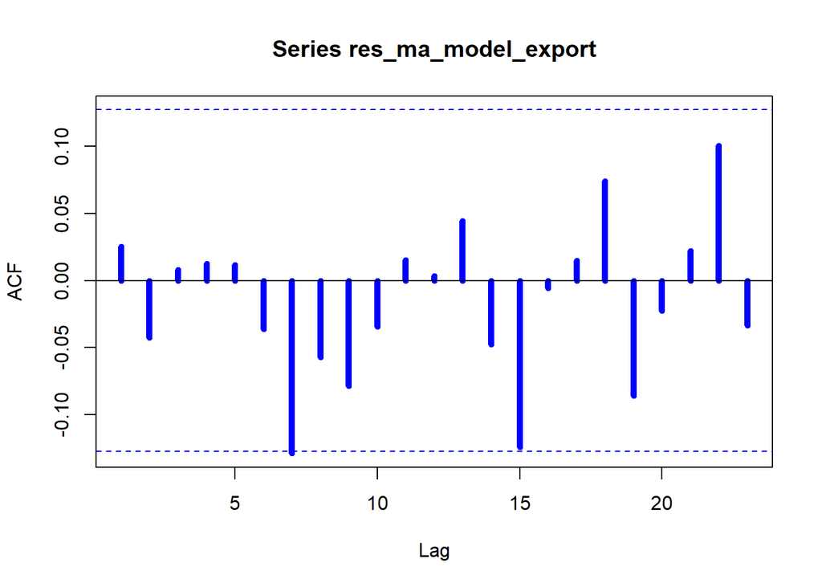

```r
acf(res_ma_model_export,lwd = 5, col = "blue")
```

Видно, что остатки выходят за доверительный интервал

```r
Box.test(res_ma_model_export, lag = 52, type = "Ljung-Box", fitdf = 2)
```

```
##
##  Box-Ljung test
##
## data:  res_ma_model_export
## X-squared = 47.189, df = 50, p-value = 0.5869
```

Не отвергаем гипотезу о случайности остатков

```r
k3<- kernel('daniell',c(5,5,5))
sp_ma=spec(res_ma_model_export,kernel=k3,log='no',sub='',xlab='Frequency',
        ylab='Smoothed Sample Spectral Density',col = "blue",lwd = 2)
```

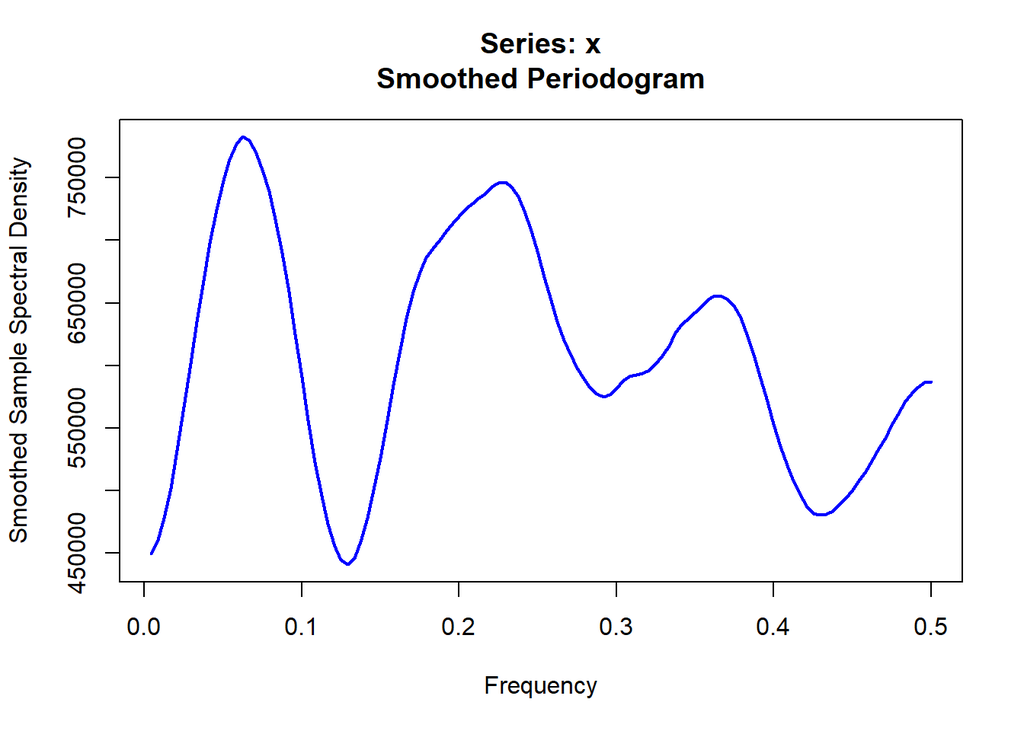

Посмотрим на сглаженную спектральную плотность исходного ряда и остатков всех трех моделей для сравнения

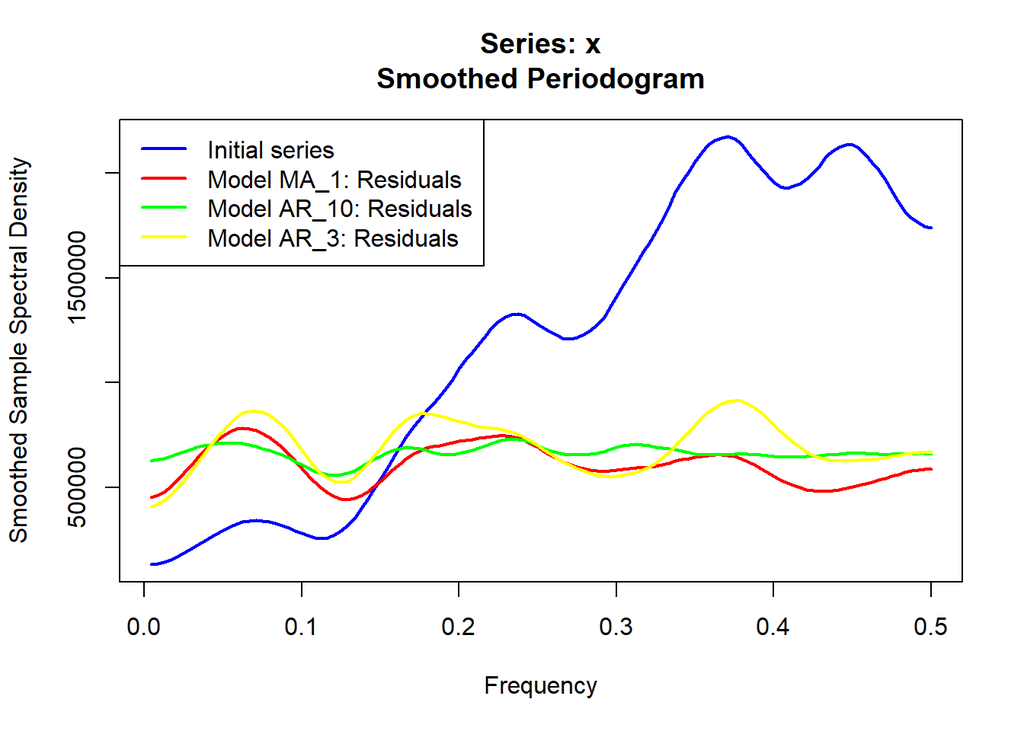

```r
sp_zz = spec(zz,kernel=k3,log='no',sub='',xlab='Frequency',
                       ylab='Smoothed Sample Spectral Density',col = "blue",lwd = 2)
lines(sp_ma$freq,sp_ma$spec,col='red',lwd=2)
lines(sp$freq,sp$spec,col='green',lwd=2)
lines(sp_2$freq,sp_2$spec,col='yellow',lwd=2)
legend("topleft",c("Initial series","Model MA_1: Residuals", "Model AR_10: Residuals", "Model AR_3: Residuals"),lwd = 2,col=c("blue","red", "green", "yellow"))
```

Видим, что ближе всего к белому шуму остатки первой модели. Кроме того, они все лежат внутри доверительного интервала. Будем использовать для прогнозирования первую модель: авторегрессию 10-го порядка несезонной компоненты и 1-го порядка сезонной компоненты с периодичностью 52

# Прогнозирование

Определим вспомогательную функцию для создания векторов с прогнозами и временным рядом

```r
getVector <- function(vv, bInd, l) {
  c <- vector()
  if (bInd > 1) {
    c <- rep(NA, bInd - 1)
  }
  res <- c(c, vv)
  cc <- vector()
  cc <- rep(NA, l - length(res))
  res <- c(res, cc)
  return(res)
}
```

Определяем длину временного ряда и количество точек для прогноза (52 недели вперёд)

```r
lzz <- length(zz)
nforec <- 52  # Прогнозируем на один сезонный период
ll <- lzz + nforec
```

Выполняем прогноз на 52 недели вперёд с помощью модели

```r
forec_export <- predict(ar_model_export, n.ahead = nforec)
vec1 <- getVector(zz, 1, ll)
vec2 <- getVector(forec_export$pred, lzz + 1, ll)
vec3 <- getVector(zz, 1, ll)
```

```r
q <- qnorm(0.75, 0, 1)
dPl <- forec_export$pred + forec_export$se * q
dMn <- forec_export$pred - forec_export$se * q
vec4 <- getVector(dPl, lzz + 1, ll)
vec5 <- getVector(dMn, lzz + 1, ll)
```

Построим графики прогнозов, временного ряда и доверительных интервалов

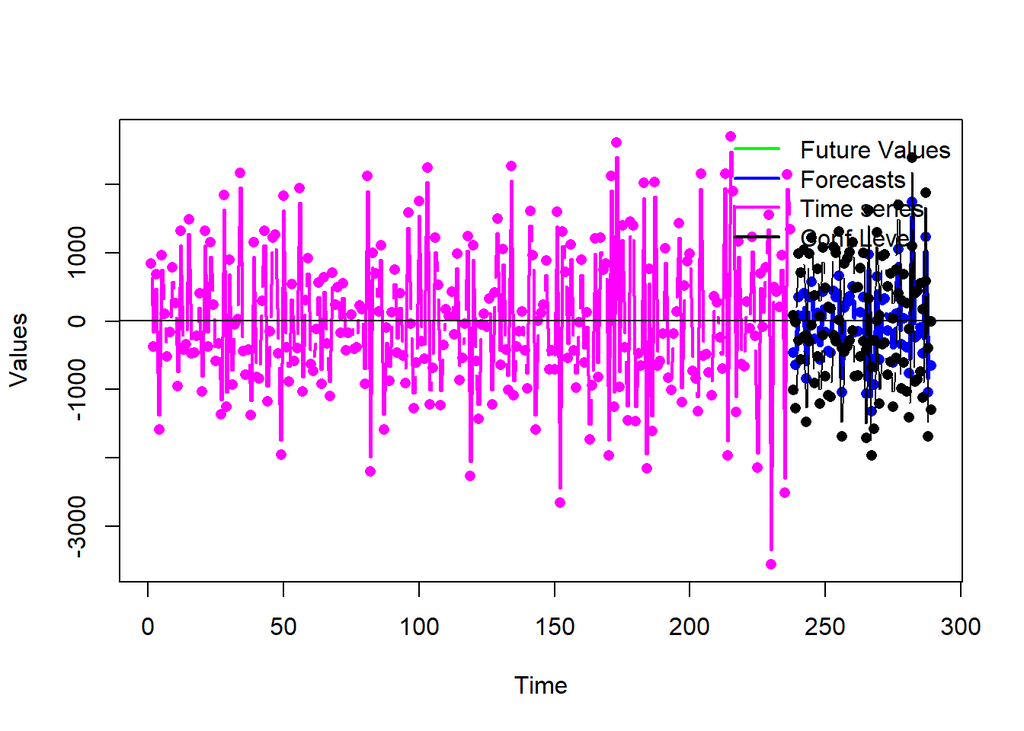

```r
res <- cbind(vec1, vec2, vec3, vec4, vec5)
matplot(res, type = c("b", "b", "b", "b", "b"), pch = 16, lty = 1,
        lwd = c(2, 3, 2, 1, 1), ylab = "Values", xlab = "Time",
        col = c("green", "blue", "magenta", "black", "black"))
abline(h = coef(ar_model_export)[names(coef(ar_model_export)) == 'intercept'])
legend("topright", c("Future Values", "Forecasts", "Time series", "Conf.Level"),
       bty = "n", lwd = 2, col = c("green", "blue", "magenta", "black"))
```

Теперь нужно выполнить обратное дифференцирование прогнозов

```r
first_y <- y[1:52]
iiy <- c(z, forec_export$pred)
iPl <- c(z, dPl)
iMn <- c(z, dMn)
```

Восстанавливаем временной ряд после первого и сезонного дифференцирования с помощью diffinv()

```r
iforec <- diffinv(iiy, lag = 52, differences = 1, first_y)
iforecPl <- diffinv(iPl, lag = 52, differences = 1, first_y)
iforecMn <- diffinv(iMn, lag = 52, differences = 1, first_y)
```

Восстанавливаем исходный временной ряд, включая первое дифференцирование

```r
first_data <- export_data[1]
imforec <- diffinv(iforec, lag = 1, differences = 1, first_data)
imforecPl <- diffinv(iforecPl, lag = 1, differences = 1, first_data)
imforecMn <- diffinv(iforecMn, lag = 1, differences = 1, first_data)
```

Преобразуем данные обратно в временные ряды для отображения

```r
imforec <- ts(imforec, start = c(2017, 1), frequency = 52)
imforecPl <- ts(imforecPl, start = c(2017, 1), frequency = 52)
imforecMn <- ts(imforecMn, start = c(2017, 1), frequency = 52)
```

Построим финальный график прогноза временного ряда, доверительных интервалов и исходных данных

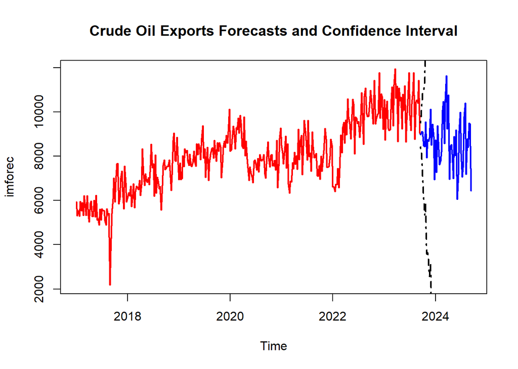

```r
# Устанавливаем NA для прогнозных значений
imforecPl[1:length(export_data)] <- NA
imforecMn[1:length(export_data)] <- NA

# Построение графика с прогнозами и доверительными интервалами
plot(imforec, col = "blue", lwd = 2, type = "l",
     main = "Crude Oil Exports Forecasts and Confidence Interval")
lines(export_data, lwd = 2, col = "red")
lines(imforecPl, lwd = 2, lty = 4, col = "black")
lines(imforecMn, lwd = 2, lty = 4, col = "black")
```

Теперь построим сезонную мультипликативную модель Хольта-Уинтерса и спрогнозируем значения на 52 недели вперед

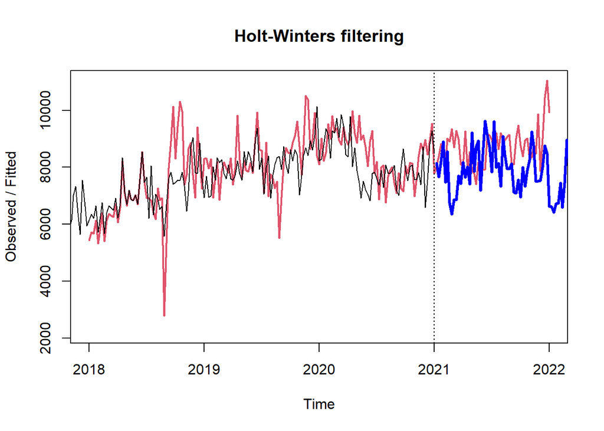

```r
past <- window(export_data, end = c(2021,1))
future <- window(export_data, start = c(2021,2))
model <- HoltWinters(past, seasonal = "mult")
pred <- predict(model, n.ahead=52)
plot(model,predicted.values = pred,lwd=2)
lines(future,col = "blue",lwd = 3)
```

Видим, что на несколько недель вперед неплохо спрогнозировали, но на большой период удачно спрогнозировать не удалось